# A3: Incarceration

### Introduction

```r
library(dplyr)
wapopdata <- read.csv("https://raw.githubusercontent.com/melaniewalsh/Neat-Datasets/main/us-prison-jail-rates-1990-WA.csv")
```

In the context of the U.S.’s high incarceration rates, this study focuses on the unique trends in Washington State. We will analyze the ‘Year’, ‘Total_prison_pop’, ‘Total_jail_pop’ and ‘Jail_pop_rate’ variables to understand temporal trends in Washington’s incarceration rates and their impact on the state’s policies. I am going to caluculate the average value jail rate, highest value jail rate, lowest value jail rate, and the median jail rate.

### Summary Information

```r
library(dplyr)
library(ggplot2)
average_value_jail <- wapopdata %>%
  filter(year == max(year)) %>%
  summarise(mean(total_jail_pop_rate, na.rm = TRUE))

highest_value_jail <- wapopdata %>%
  filter(total_jail_pop_rate == max(total_jail_pop_rate, na.rm = TRUE))

lowest_value_jail <- wapopdata %>%
  filter(total_jail_pop_rate == min(total_jail_pop_rate, na.rm = TRUE))

change_over_years_jail <- wapopdata %>%
  filter(year %in% c(max(year) - 10, max(year))) %>%
  group_by(year) %>%
  summarise(Avg = mean(total_jail_pop_rate, na.rm = TRUE)) %>%
  summarise(Change = diff(Avg))

Median_value_jail <- wapopdata %>%
  filter(total_jail_pop_rate == median(total_jail_pop_rate, na.rm = TRUE))

max_jail_rate <- max(wapopdata$total_jail_pop_rate, na.rm = TRUE)
min_jail_rate <- min(wapopdata$total_jail_pop_rate, na.rm = TRUE)
mean_jail_rate <- mean(wapopdata$total_jail_pop_rate, na.rm = TRUE)
max_year <- max(wapopdata$year, na.rm = TRUE)
min_year <- min(wapopdata$year, na.rm = TRUE)
```

In analyzing incarceration rates in Washington State, I found that the average jail population rate for the most recent year in the data set was 326.6744. The highest jail population rate observed was in County Yakima with a rate of 992.82, while the lowest rate was in Whitman County with a rate of 95.94. Over the last ten years, the average jail population rate has changed by -8.747692. The median jail rate is approximately 298.44.

### The Dataset

The data was collected by the Vera Institute of Justice.The data was generated from two primary sources: the Census of Jails (COJ) and the Annual Survey of Jails (ASJ). There are 23 column, and 1131 rows in the data set. When dealing with data on incarceration rates, a multitude of ethical considerations and power dynamics are involved. To start with, such data inherently touches on sensitive societal issues related to racial and socio-economic disparities, policy decisions, and systemic inequities. Misinterpretation or misuse of such data could inadvertently support harmful narratives or perpetuate systemic biases.In terms of power,incarceration data is typically collected and controlled by governmental or institutional entities. This might result in potential bias or discrepancy in data due to differences in data collection standards, interpretation, or transparency across different entities.In addition,data that relies on self-reporting from institutions can sometimes be skewed due to attempts to manage reputations or meet specific policy goals.Moreover, policy makers and researchers with access to this data hold significant power over how the data is interpreted and communicated to the public, further emphasizing the need for careful, unbiased analysis.The limitations or potential problems with this dataset could include inaccuracies due to underreporting or overreporting, discrepancies in how different counties or states report their data, lack of granularity such as individual demographics, and the specifics of the offense.

### Trends Over Time Chart

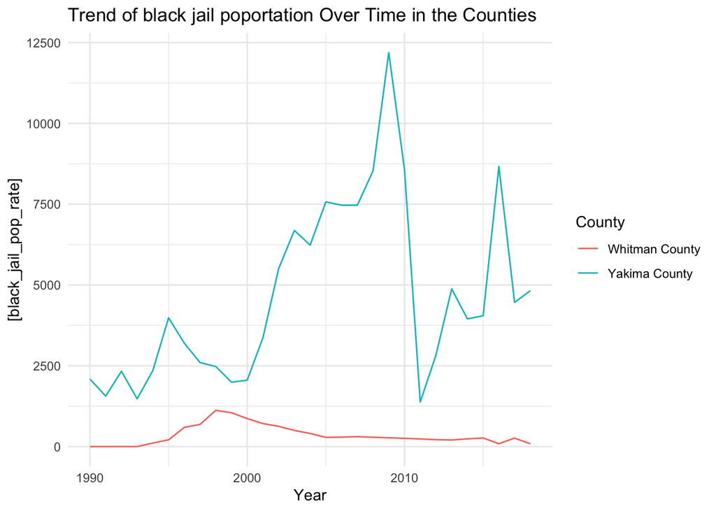

```r
library(dplyr)
library(ggplot2)
selected_data <- wapopdata %>%
  filter(county_name %in% c("Yakima County", "Whitman County"))

ggplot(data = selected_data, aes(x = year, y = black_jail_pop_rate, color = county_name)) +
  geom_line() +
  labs(title = "Trend of black jail poportation Over Time in the Counties",
       x = "Year",
       y = "[black_jail_pop_rate]",
       color = "County")+
theme_minimal()
```

### Variable Comparison Chart

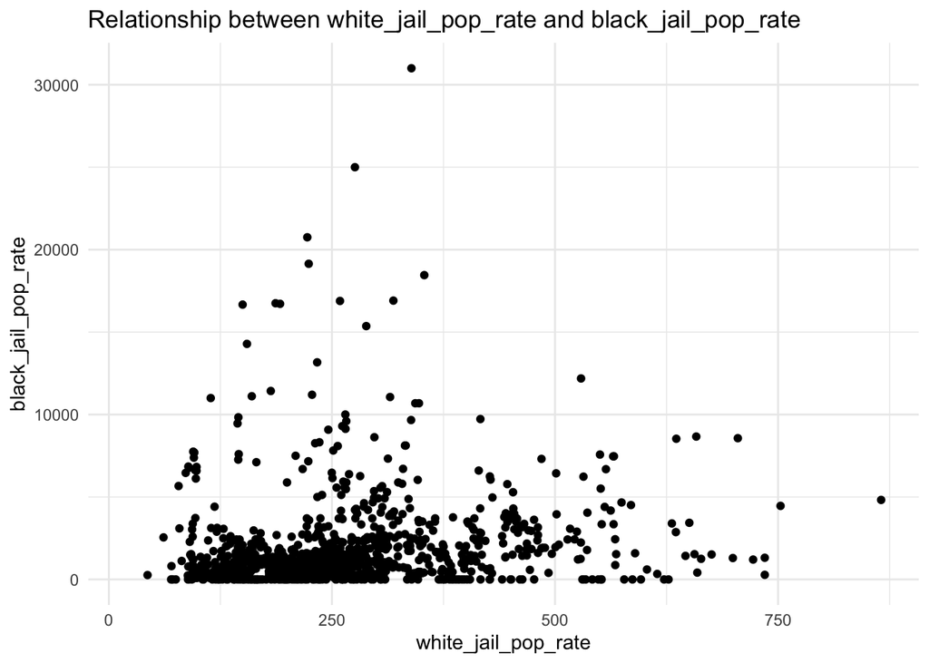

```r
library(dplyr)
library(ggplot2)
ggplot(data = wapopdata, aes(x = white_jail_pop_rate, y = black_jail_pop_rate)) +
  geom_point() +
  labs(title = "Relationship between white_jail_pop_rate and black_jail_pop_rate",
       x = "white_jail_pop_rate",
       y = "black_jail_pop_rate",
       color = "[Category Variable Description]")+
  theme_minimal()
```

For this graph, I want to see whether there is relationship between those two variable. From the chart, we can see that the two varible did have no clear shape in the scatter graph above, which means those two are not directly related to each other it may change over time, becasue each year the policy are changing, so we could not make a conclusion that those two variable has a relationship.

### Map

[figure not shown]

```r
library(dplyr)
library(ggplot2)
wapopdata$county <- tolower(wapopdata$county)
wapopdata$county <- gsub(" ", "", wapopdata$county)
wapopdata$region <- paste("washington,", wapopdata$county, sep = "")

wa_map <- map_data("county", region = "washington")

merged_data <- merge(wa_map, wapopdata, by.x = "region", by.y = "county", all.x = TRUE)

ggplot() +
  geom_polygon(data = merged_data,
               aes(x = long, y = lat, group = group, fill = total_jail_pop_rate),
               color = "yellow", size = 0.2) +
  coord_map() +
  labs(title = "Distribution of Jail Population in Washington State",
       fill = "Jail Population",
       x = "Longitude",
       y = "Latitude",
       scale_fill_gradient(low = "blue", high = "red")
  ) + theme_minimal()
```